# Code Recreation for Final Project

Divide paper into five parts: - Preliminary Data Science - Feature Selection - Base Model Creation - Feature Selected Model Creation - Model Comparison

# 1. PRELIMINARY ACTIONS

Goals: Get lung cancer dataset ready for modeling and perform exploratory data analysis

## a. Data Cleaning for Modeling

```r
# --- PACKAGES ---

# Clear environment
remove(list=ls())

# Starter libraries (new ones will be added as used)
library(tidyverse)
library(dplyr)
library(knitr)
library(kableExtra)
library(rsample) # Data split
library(ggplot2)
library(corrplot)
library(pROC) # ROC curves
library(randomForest)
```

```r
# --- GET DATA ---
lung_cancer <- read.csv("final_dataset.csv")
```

The data was preprocessed so that no NA values are present, potentially significant columns are chosen, and all instances of observations diagnosed with lung cancer are included in our dataset along with a proportional, matched group of non-cancer instances, which were found using the nonparametric matching system MatchIt.

```r
# --- INITIAL DATA CLEANING ---
lung_cancer <- lung_cancer %>%
  select(!X) %>% # Remove column number from download
  select(!SEQNO) %>% # Remove observation ID
  mutate(GENDER = ifelse(GENDER == "Male", 1, 0), # Change gender to binary feature
         LUNG_CANCER = as.factor(ifelse(LUNG_CANCER == 1, "Yes", "No")), # Change lung cancer indicator to Yes/No for models
         AGE_GROUP = as.factor(AGE_GROUP)) # Change age group indicator to factor
```

```r
# --- DATA SUMMARY ---
summary(lung_cancer)
```

```
 LUNG_CANCER      COPD            ASTHMA           SMOKER       POOR_PHYS_DAYS       HEIGHT
 No :991     Min.   :0.0000   Min.   :0.0000   Min.   :0.0000   Min.   : 0.000   Min.   :53
 Yes:355     1st Qu.:0.0000   1st Qu.:0.0000   1st Qu.:0.0000   1st Qu.: 0.000   1st Qu.:63
             Median :0.0000   Median :0.0000   Median :1.0000   Median : 0.000   Median :66
             Mean   :0.2296   Mean   :0.1672   Mean   :0.5342   Mean   : 6.895   Mean   :66
             3rd Qu.:0.0000   3rd Qu.:0.0000   3rd Qu.:1.0000   3rd Qu.:10.000   3rd Qu.:69
             Max.   :1.0000   Max.   :1.0000   Max.   :1.0000   Max.   :30.000   Max.   :84
     WEIGHT            BMI        AGE_GROUP        GENDER         EXERCISE         SMOKE100
 Min.   :  80.0   Min.   :13.72   25-34:   8   Min.   :0.000   Min.   :0.0000   Min.   :0.0000
 1st Qu.: 145.0   1st Qu.:23.78   35-44:   3   1st Qu.:0.000   1st Qu.:0.0000   1st Qu.:0.0000
 Median : 170.0   Median :27.04   45-54:  19   Median :0.000   Median :1.0000   Median :1.0000
 Mean   : 188.5   Mean   :28.18   55-64: 277   Mean   :0.347   Mean   :0.6538   Mean   :0.5342
 3rd Qu.: 200.0   3rd Qu.:31.19   65+  :1039   3rd Qu.:1.000   3rd Qu.:1.0000   3rd Qu.:1.0000
 Max.   :9220.0   Max.   :70.86                Max.   :1.000   Max.   :1.0000   Max.   :1.0000
     ECIGS         SMOKELESS_TOBACCO    COVID19
 Min.   :0.00000   Min.   :0.00000   Min.   :0.0000
 1st Qu.:0.00000   1st Qu.:0.00000   1st Qu.:0.0000
 Median :0.00000   Median :0.00000   Median :0.0000
 Mean   :0.01783   Mean   :0.01412   Mean   :0.4421
 3rd Qu.:0.00000   3rd Qu.:0.00000   3rd Qu.:1.0000
 Max.   :1.00000   Max.   :1.00000   Max.   :1.0000
```

## b. Exploratory Data Analysis

The next two code chunks replicate a visualization made by our parent paper, which plots how much of each age group had lung cancer or not.

```r
# --- OBTAIN LUNG CANCER PREVALENCE BY AGE GROUP ---
age_group_pct <- lung_cancer %>%
  group_by(AGE_GROUP, LUNG_CANCER) %>%
  summarize(Count = n(),
            Ratio = Count / nrow(lung_cancer))
```

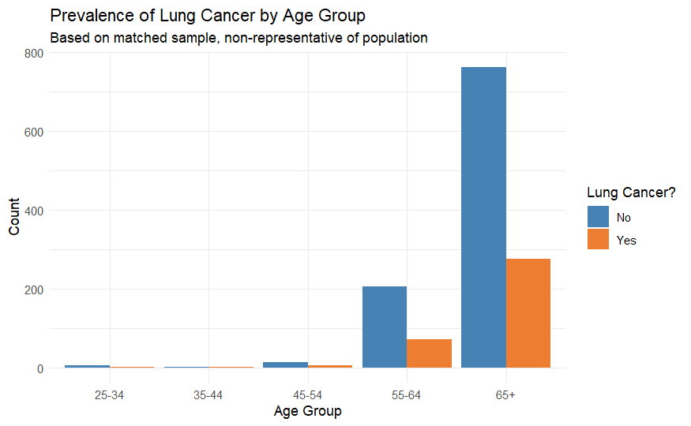

```r
# --- PLOT LUNG CANCER PREVALENCE BY AGE GROUP
ggplot(data=age_group_pct, aes(x=AGE_GROUP, y=Count, fill=LUNG_CANCER)) +
  geom_col(position = "dodge") +
  scale_fill_manual(values=c("No" = "steelblue", "Yes" = "#ED7D31")) +
  labs(title = "Prevalence of Lung Cancer by Age Group",
       subtitle = "Based on matched sample, non-representative of population",
       x = "Age Group", y = "Count", fill = "Lung Cancer?") +
  theme_minimal()
```

The next chunk generates a correlation plot to check possible blocks to significance.

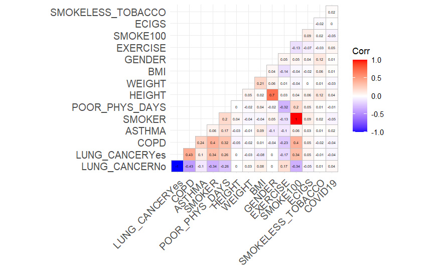

```r
library(ggcorrplot)

model.matrix(~0+., data=lung_cancer %>% select(!AGE_GROUP)) %>%
  cor(use="pairwise.complete.obs") %>%
  ggcorrplot(show.diag=FALSE, type="lower", lab=TRUE, lab_size=1.5)
```

Since smoking ever has a 100% correlation with smoking in the last 100 days, we can remove SMOKE100 from our analysis so that there is no noise preventing smoking from being potentially significant.

```r
# SMOKE100 is, for the purposes of modeling, the same variable as SMOKER
# BMI plays directly into height and weight, removing HEIGHT and WEIGHT as well
model_data <- lung_cancer %>%
  select(!SMOKE100) %>%
  select(!HEIGHT) %>%
  select(!WEIGHT)
```

# 2. FEATURE SELECTION

Goal: Create multiple metrics pointing us towards significant features to select

## a. Random Forest and Gain Ratio

The random forest score is calculated using Gini.

```r
# --- RANDOM FOREST ---
set.seed(123)

# Make a random forest model
rf_model <- randomForest(
  LUNG_CANCER ~ .,
  data = model_data,
  importance = TRUE,
  ntree = 500
)

# Obtain importance scores
rf_importance <- importance(rf_model, type = 2) %>%
  as.data.frame() %>%
  rownames_to_column("Feature") %>%
  rename(RF_Ranking = MeanDecreaseGini) %>%
  arrange(desc(RF_Ranking))

rf_importance
```

| Feature | RF_Ranking |
| --- | --- |
| BMI | 95.416756 |
| COPD | 67.567499 |
| POOR_PHYS_DAYS | 53.575869 |
| SMOKER | 35.927584 |
| AGE_GROUP | 15.346548 |
| EXERCISE | 13.367249 |
| COVID19 | 12.010709 |
| GENDER | 11.992347 |
| ASTHMA | 10.171881 |
| ECIGS | 3.361217 |

[output cut: 1 more lines]

The code below creates the Gain Ratio function.

```r
# --- GAIN RATIO ---
# Formula: GR(f_i) = [H(c) - H(c|f_i)] / H(f_i)

# Entropy function: H(X) = -sum(p * log2(p))
entropy <- function(x) {
  probs <- table(x) / length(x)
  probs <- probs[probs > 0]  # avoid log(0)
  -sum(probs * log2(probs))
}

# Conditional entropy function: H(c|f) = sum over f's values of P(f=v) * H(c | f=v)
conditional_entropy <- function(class_var, feature_var) {
  levels_f <- unique(feature_var)
  total_n <- length(feature_var)
  cond_h <- 0
  for (v in levels_f) {
    subset_class <- class_var[feature_var == v]
    weight <- length(subset_class) / total_n
    cond_h <- cond_h + weight * entropy(subset_class)
  }
  return(cond_h)
}

# Gain Ratio function for one feature
gain_ratio_single <- function(class_var, feature_var) {
  h_c <- entropy(class_var)
  h_c_given_f <- conditional_entropy(class_var, feature_var)
  h_f <- entropy(feature_var)
  info_gain <- h_c - h_c_given_f

  # Avoid divide-by-zero if feature has only 1 unique value
  if (h_f == 0) {return(0)}
  gr <- info_gain / h_f
  return(gr)
}
```

The code below implements Gain Ratio.

```r
# Obtain feature names
feature_names <- setdiff(names(model_data), "LUNG_CANCER")
class_var <- model_data$LUNG_CANCER

# Apply gain ratio scores
gr_scores <- sapply(feature_names, function(f) {
  gain_ratio_single(class_var, model_data[[f]])
})

# Create data frame for gain ratio scores
gain_ratio_result <- data.frame(
  Feature = names(gr_scores),
  GR_Ranking = round(as.numeric(gr_scores), 4)
) %>%
  arrange(desc(GR_Ranking))

gain_ratio_result
```

| Feature | GR_Ranking |
| --- | --- |
| COPD | 0.1544 |
| SMOKER | 0.0872 |
| BMI | 0.0467 |
| POOR_PHYS_DAYS | 0.0243 |
| EXERCISE | 0.0210 |
| ECIGS | 0.0111 |
| ASTHMA | 0.0101 |
| SMOKELESS_TOBACCO | 0.0015 |
| COVID19 | 0.0012 |
| AGE_GROUP | 0.0001 |

[output cut: 1 more lines]

The code below combines both metrics into a table.

```r
feature_rankings <- rf_importance %>%
  left_join(gain_ratio_result, by=join_by("Feature"=="Feature"))
```

## b. Forwards Elimination

Goal: Create a base model, a finished full model, and work our way between.

```r
library(stats)

# Base model with only intercept
base_model <- glm(LUNG_CANCER ~ 1, family = binomial, data = model_data)

# Full model with all potential predictors
full_model <- glm(LUNG_CANCER ~ ., family = binomial, data = model_data)
```

```r
# Forward elimination
forwards_elim <- stats::step(object = base_model,
                             scope = list(lower = base_model, upper = full_model),
                             data = model_data,
                             direction = "forward")
```

```
Start:  AIC=1555.11
LUNG_CANCER ~ 1

                    Df Deviance    AIC
+ COPD               1   1329.2 1333.2
+ SMOKER             1   1390.9 1394.9
+ POOR_PHYS_DAYS     1   1468.2 1472.2
+ EXERCISE           1   1516.6 1520.6
+ ASTHMA             1   1540.9 1544.9
+ BMI                1   1543.0 1547.0
+ ECIGS              1   1550.4 1554.4
+ COVID19            1   1550.9 1554.9
<none>                   1553.1 1555.1
+ SMOKELESS_TOBACCO  1   1552.8 1556.8
+ GENDER             1   1553.1 1557.1
+ AGE_GROUP          4   1552.9 1562.9

Step:  AIC=1333.17
LUNG_CANCER ~ COPD

                    Df Deviance    AIC
+ SMOKER             1   1270.6 1276.6
+ POOR_PHYS_DAYS     1   1304.1 1310.1
+ BMI                1   1316.7 1322.7
+ EXERCISE           1   1321.7 1327.7
<none>                   1329.2 1333.2
+ ECIGS              1   1328.1 1334.1
+ COVID19            1   1328.2 1334.2
+ GENDER             1   1328.6 1334.6
+ SMOKELESS_TOBACCO  1   1329.1 1335.1
+ ASTHMA             1   1329.2 1335.2
+ AGE_GROUP          4   1328.1 1340.1

Step:  AIC=1276.56
LUNG_CANCER ~ COPD + SMOKER

                    Df Deviance    AIC
+ POOR_PHYS_DAYS     1   1249.9 1257.9
+ BMI                1   1261.0 1269.0
+ EXERCISE           1   1264.7 1272.7
```

[output cut: 31 more lines]

```
+ ECIGS              1   1238.9 1250.9
+ ASTHMA             1   1238.9 1250.9
+ AGE_GROUP          4   1236.9 1254.9

Step:  AIC=1248.08
LUNG_CANCER ~ COPD + SMOKER + POOR_PHYS_DAYS + BMI + EXERCISE

                    Df Deviance    AIC
<none>                   1236.1 1248.1
+ COVID19            1   1235.6 1249.6
+ GENDER             1   1235.8 1249.8
+ SMOKELESS_TOBACCO  1   1235.9 1249.9
+ ECIGS              1   1236.1 1250.1
+ ASTHMA             1   1236.1 1250.1
+ AGE_GROUP          4   1233.9 1253.9
```

```r
forwards_elim$coefficients
```

```
   (Intercept)           COPD         SMOKER POOR_PHYS_DAYS            BMI       EXERCISE
   -1.14674524     1.46866655     1.13277306     0.02631002    -0.03889195    -0.26042909
```

## c. Backwards Selection

```r
# Backwards elimination
backwards_elim <- stats::step(object = full_model,
                              scope = formula(full_model),
                              data = model_data,
                              direction = "backward",
                              trace = 0)
```

```r
backwards_elim$coefficients
```

```
   (Intercept)           COPD         SMOKER POOR_PHYS_DAYS            BMI       EXERCISE
   -1.14674524     1.46866655     1.13277306     0.02631002    -0.03889195    -0.26042909
```

## Summary Table

```r
# 1 (Yes) or 0 (No): Were the variables from Gain Ratio table chosen by each selection model?
forwards_chosen  <- c("Yes", "Yes", "Yes", "Yes", "No", "Yes", "No", "No", "No", "No", "No")
backwards_chosen <- c("Yes", "Yes", "Yes", "Yes", "No", "Yes", "No", "No", "No", "No", "No")

feature_rankings <- feature_rankings %>%
  mutate(ForwardSelect = forwards_chosen,
         BackwardSelect = backwards_chosen)
```

```r
kable(feature_rankings,
      col.names = c("Feature", "Random Forest Score", "Gain Ratio Score", "Forwards Selection", "Backwards Selection"),
      align = c("l", "c", "c", "c", "c"))
```

| Feature | Random Forest Score | Gain Ratio Score | Forwards Selection | Backwards Selection |
| --- | --- | --- | --- | --- |
| BMI | 95.416756 | 0.0467 | Yes | Yes |
| COPD | 67.567499 | 0.1544 | Yes | Yes |
| POOR_PHYS_DAYS | 53.575870 | 0.0243 | Yes | Yes |
| SMOKER | 35.927584 | 0.0872 | Yes | Yes |
| AGE_GROUP | 15.346548 | 0.0001 | No | No |
| EXERCISE | 13.367249 | 0.0210 | Yes | Yes |
| COVID19 | 12.010708 | 0.0012 | No | No |
| GENDER | 11.992347 | 0.0000 | No | No |
| ASTHMA | 10.171881 | 0.0101 | No | No |
| ECIGS | 3.361217 | 0.0111 | No | No |
| SMOKELESS_TOBACCO | 2.081059 | 0.0015 | No | No |

Our selected features will be the five that feature in the top six of both random forest and gain ratio, and the five which were selected by both models: BMI, COPD, POOR_PHYS_DAYS, SMOKER, EXERCISE

```r
selected_data <- model_data %>%
  select(LUNG_CANCER, COPD, SMOKER, POOR_PHYS_DAYS, BMI, EXERCISE)
```

# 3. MODELS WITHOUT FEATURE SELECTION

```r
# General
library(tidyverse)
library(dplyr)
library(knitr)
library(kableExtra)
library(rsample) # Data split
library(ggplot2)
library(corrplot)
library(pROC) # ROC curves

# ML Model Packages
library(randomForest)
library(caret) # for regression
library(naivebayes)
library(discretization) # For supervised discretization (MDLP method)
library(bnlearn) # BayesNet
library(LiblineaR) # SGD
library(e1071) # SVM
library(glmnet) # Logistic Regression
library(nnet) # Neural networks
library(C50) # J48
library(partykit) # LMT
library(rpart) # REPTree
library(rotationForest)
```

## Data Split

```r
set.seed(123)

split <- sample(c(TRUE, FALSE), nrow(model_data), replace=TRUE, prob=c(0.75, 0.25))

train_set <- model_data[split, ]
test_set <- model_data[!split, ]

train_selected <- selected_data[split, ]
test_selected <- selected_data[!split, ]
```

## Create Training Controls

```r
set.seed(123)
cv_folds <- createFolds(train_set$LUNG_CANCER, k = 10, returnTrain = TRUE)

train_ctrl <- trainControl(
  method = "cv",
  index = cv_folds,
  classProbs = TRUE,
  summaryFunction = twoClassSummary,
  savePredictions = "final",
  verboseIter = FALSE
)
```

## Naive Bayes

```r
symptom_cols <- c("COPD", "ASTHMA", "SMOKER", "AGE_GROUP", "GENDER",
                  "EXERCISE", "ECIGS", "SMOKELESS_TOBACCO", "COVID19")

for (col in symptom_cols) {
  train_set[[col]] <- factor(train_set[[col]])
  test_set[[col]]  <- factor(test_set[[col]], levels = levels(train_set[[col]]))
}

nb_grid <- expand.grid(
  laplace = c(0, 1, 2),
  usekernel = c(FALSE, TRUE),
  adjust = c(1, 1.5)
)

set.seed(123)
nb_model <- train(
  LUNG_CANCER ~ .,
  data = train_set,
  method = "naive_bayes",
  trControl = train_ctrl,
  tuneGrid = nb_grid,
  metric = "ROC"
)

nb_preds <- predict(nb_model, newdata = test_set)
confusionMatrix(nb_preds, test_set$LUNG_CANCER, positive = "Yes")
```

```
Confusion Matrix and Statistics

          Reference
Prediction  No Yes
       No  239  85
       Yes   0   0

               Accuracy : 0.7377
                 95% CI : (0.6862, 0.7847)
    No Information Rate : 0.7377
    P-Value [Acc > NIR] : 0.5291

                  Kappa : 0

 Mcnemar's Test P-Value : <2e-16

            Sensitivity : 0.0000
            Specificity : 1.0000
         Pos Pred Value :    NaN
         Neg Pred Value : 0.7377
             Prevalence : 0.2623
         Detection Rate : 0.0000
   Detection Prevalence : 0.0000
      Balanced Accuracy : 0.5000

       'Positive' Class : Yes
```

## Bayesian Network (BayesNet)

```r
library(bnlearn)
library(pROC)
library(caret)

# 1. Prepare data frames
train_bn <- train_set
test_bn  <- test_set

# Ensure BMI is numeric before discretizing
train_bn$BMI <- as.numeric(train_bn$BMI)
test_bn$BMI  <- as.numeric(test_bn$BMI)

# Factorize all other categorical/symptom columns
factor_cols <- setdiff(names(train_bn), c("BMI", "LUNG_CANCER"))
train_bn[factor_cols] <- lapply(train_bn[factor_cols], factor)
test_bn[factor_cols]  <- lapply(test_bn[factor_cols], factor)

# 2. Discretize BMI into 3 quantile bins using bnlearn
train_bn["BMI"] <- bnlearn::discretize(
  data = train_bn["BMI"],
  method = "quantile",
  breaks = 3,
  ordered = FALSE
)

# Project training quantile boundaries onto test_set$BMI
raw_train_vals <- as.numeric(train_set$BMI)
brks <- quantile(raw_train_vals, probs = seq(0, 1, length.out = 4), na.rm = TRUE)
brks[1] <- -Inf
brks[length(brks)] <- Inf

test_bn$BMI <- cut(
  as.numeric(test_set$BMI),
  breaks = brks,
  labels = levels(train_bn$BMI),
  include.lowest = TRUE
)

# Ensure test_bn factor levels match train_bn perfectly
for (col in names(train_bn)) {
  if (is.factor(train_bn[[col]])) {
    test_bn[[col]] <- factor(test_bn[[col]], levels = levels(train_bn[[col]]))
  }
}

target_node <- "LUNG_CANCER"
bn_cv_acc <- numeric(10)

# 3. 10-Fold Cross-Validation Loop
for (i in 1:10) {
  val_idx    <- cv_folds[[i]]
  fold_train <- train_bn[val_idx, , drop = FALSE]
  fold_val   <- train_bn[-val_idx, , drop = FALSE]

  # Remove single-level columns if any exist in the fold
  single_level <- sapply(fold_train, function(x) length(unique(x)) < 2)
  if (any(single_level)) {
    fold_train <- fold_train[, !single_level, drop = FALSE]
    fold_val   <- fold_val[, intersect(names(fold_train), names(fold_val)), drop = FALSE]
  }

  # Harmonize factor levels between fold train and val
  for (col in names(fold_train)) {
    if (is.factor(fold_train[[col]])) {
      fold_val[[col]] <- factor(fold_val[[col]], levels = levels(fold_train[[col]]))
    }
  }

  # Learn structure and fit parameters
  fit_res <- tryCatch({
    dag <- hc(fold_train)
    bn.fit(dag, data = fold_train, method = "bayes", iss = 1)
  }, error = function(e) NULL)

  if (is.null(fit_res)) {
    bn_cv_acc[i] <- NA
    next
  }

  # Predict via likelihood weighting
  preds <- tryCatch({
    predict(fit_res, node = target_node, data = fold_val, method = "bayes-lw")
  }, error = function(e) NULL)

  if (!is.null(preds)) {
    bn_cv_acc[i] <- mean(preds == fold_val[[target_node]], na.rm = TRUE)
  } else {
    bn_cv_acc[i] <- NA
  }
}

cat("BayesNet 10-Fold CV Mean Accuracy:", mean(bn_cv_acc, na.rm = TRUE), "\n")
```

```
BayesNet 10-Fold CV Mean Accuracy: 0.7838473
```

```r
# 4. Final Model Training and Test Evaluation
dag_final <- hc(train_bn)
bn_final  <- bn.fit(dag_final, data = train_bn, method = "bayes", iss = 1)

bn_preds <- predict(bn_final, node = target_node, data = test_bn, method = "bayes-lw")

confusionMatrix(bn_preds, test_bn[[target_node]], positive = "Yes")
```

```
Confusion Matrix and Statistics

          Reference
Prediction  No Yes
       No  218  40
       Yes  21  45

               Accuracy : 0.8117
                 95% CI : (0.7648, 0.8528)
    No Information Rate : 0.7377
    P-Value [Acc > NIR] : 0.001106

                  Kappa : 0.4758

 Mcnemar's Test P-Value : 0.021185

            Sensitivity : 0.5294
            Specificity : 0.9121
         Pos Pred Value : 0.6818
         Neg Pred Value : 0.8450
             Prevalence : 0.2623
         Detection Rate : 0.1389
   Detection Prevalence : 0.2037
      Balanced Accuracy : 0.7208

       'Positive' Class : Yes
```

## Stochastic Gradient Descent (SGD)

```r
library(LiblineaR)
library(caret)

# ---------------------------------------------------------
# 1. Recode 0/1 to Valid R Variable Names ("No" / "Yes")
# ---------------------------------------------------------
train_sgd <- train_set
test_sgd <- test_set

if (!all(levels(train_sgd$LUNG_CANCER) %in% c("No", "Yes"))) {
  train_sgd$LUNG_CANCER <- factor(train_sgd$LUNG_CANCER,
                                  levels = c("0", "1"),
                                  labels = c("No", "Yes"))

  test_sgd$LUNG_CANCER  <- factor(test_sgd$LUNG_CANCER,
                                  levels = c("0", "1"),
                                  labels = c("No", "Yes"))
}

# ---------------------------------------------------------
# 2. Configure trainControl
# ---------------------------------------------------------
train_ctrl <- trainControl(
  method = "cv",
  number = 10,
  classProbs = TRUE,
  summaryFunction = twoClassSummary,
  savePredictions = "final",
  verboseIter = FALSE
)

# ---------------------------------------------------------
# 3. Train Regularized Logistic Regression (SGD Equivalent)
# ---------------------------------------------------------
set.seed(123)
sgd_model <- train(
  LUNG_CANCER ~ .,
  data = train_sgd,
  method = "regLogistic",
  preProcess = c("center", "scale"),
  tuneGrid = expand.grid(
    cost = 1 / (1e-4 * nrow(train_sgd)),
    loss = "L2_dual",
    epsilon = 0.01
  ),
  trControl = train_ctrl,
  metric = "ROC"
)

# ---------------------------------------------------------
# 4. Predict & Evaluate
# ---------------------------------------------------------
sgd_preds <- predict(sgd_model, newdata = test_sgd)

# positive = "Yes" matches the second factor level
conf_matrix_sgd <- confusionMatrix(sgd_preds, test_sgd$LUNG_CANCER, positive = "Yes")
print(conf_matrix_sgd)
```

```
Confusion Matrix and Statistics

          Reference
Prediction  No Yes
       No  222  46
       Yes  17  39

               Accuracy : 0.8056
                 95% CI : (0.7582, 0.8472)
    No Information Rate : 0.7377
    P-Value [Acc > NIR] : 0.0026386

                  Kappa : 0.4356

 Mcnemar's Test P-Value : 0.0004192

            Sensitivity : 0.4588
            Specificity : 0.9289
         Pos Pred Value : 0.6964
         Neg Pred Value : 0.8284
             Prevalence : 0.2623
         Detection Rate : 0.1204
   Detection Prevalence : 0.1728
      Balanced Accuracy : 0.6938

       'Positive' Class : Yes
```

## Support Vector Machine (SVM)

```r
svm_model <- train(
  LUNG_CANCER ~ .,
  data = train_sgd,
  method = "svmLinear2", # Uses e1071 backend instead of kernlab
  preProcess = c("center", "scale"),
  tuneGrid = expand.grid(cost = 1.0),
  trControl = train_ctrl,
  probability = TRUE
)

svm_preds <- predict(svm_model, newdata = test_sgd)

conf_matrix_svm <- confusionMatrix(svm_preds, test_sgd$LUNG_CANCER)
print(conf_matrix_svm)
```

```
Confusion Matrix and Statistics

          Reference
Prediction  No Yes
       No  212  37
       Yes  27  48

               Accuracy : 0.8025
                 95% CI : (0.7549, 0.8444)
    No Information Rate : 0.7377
    P-Value [Acc > NIR] : 0.003965

                  Kappa : 0.4695

 Mcnemar's Test P-Value : 0.260589

            Sensitivity : 0.8870
            Specificity : 0.5647
         Pos Pred Value : 0.8514
         Neg Pred Value : 0.6400
             Prevalence : 0.7377
         Detection Rate : 0.6543
   Detection Prevalence : 0.7685
      Balanced Accuracy : 0.7259

       'Positive' Class : No
```

## Logistic Regression

```r
lr_model <- train(
  LUNG_CANCER ~ .,
  data = train_sgd,
  method = "glmnet",
  family = "binomial",
  tuneGrid = expand.grid(alpha = 0, lambda = 1e-8),
  trControl = train_ctrl
)

glm_preds <- predict(lr_model, newdata = test_sgd)

conf_matrix_lr <- confusionMatrix(glm_preds, test_sgd$LUNG_CANCER)
print(conf_matrix_lr)
```

```
Confusion Matrix and Statistics

          Reference
Prediction  No Yes
       No  222  48
       Yes  17  37

               Accuracy : 0.7994
                 95% CI : (0.7516, 0.8416)
    No Information Rate : 0.7377
    P-Value [Acc > NIR] : 0.0058521

                  Kappa : 0.4127

 Mcnemar's Test P-Value : 0.0001984

            Sensitivity : 0.9289
            Specificity : 0.4353
         Pos Pred Value : 0.8222
         Neg Pred Value : 0.6852
             Prevalence : 0.7377
         Detection Rate : 0.6852
   Detection Prevalence : 0.8333
      Balanced Accuracy : 0.6821

       'Positive' Class : No
```

## Artificial Neural Network (ANN)

```r
num_attributes <- ncol(train_set) - 1
num_classes    <- length(levels(train_set$LUNG_CANCER))
hidden_a       <- round((num_attributes + num_classes) / 2)

ann_model <- train(
  LUNG_CANCER ~ .,
  data = train_sgd,
  method = "nnet",
  preProcess = c("center", "scale"),
  tuneGrid = expand.grid(size = hidden_a, decay = 0.0),
  maxit = 500,
  trace = FALSE,
  trControl = train_ctrl
)

ann_preds <- predict(ann_model, newdata = test_sgd)

conf_matrix_ann <- confusionMatrix(ann_preds, test_sgd$LUNG_CANCER)
print(conf_matrix_ann)
```

```
Confusion Matrix and Statistics

          Reference
Prediction  No Yes
       No  213  48
       Yes  26  37

               Accuracy : 0.7716
                 95% CI : (0.722, 0.8162)
    No Information Rate : 0.7377
    P-Value [Acc > NIR] : 0.09104

                  Kappa : 0.3562

 Mcnemar's Test P-Value : 0.01464

            Sensitivity : 0.8912
            Specificity : 0.4353
         Pos Pred Value : 0.8161
         Neg Pred Value : 0.5873
             Prevalence : 0.7377
         Detection Rate : 0.6574
   Detection Prevalence : 0.8056
      Balanced Accuracy : 0.6633

       'Positive' Class : No
```

## K-nearest neighbors (KNN)

```r
knn_model <- train(
  LUNG_CANCER ~ .,
  data = train_sgd,
  method = "knn",
  preProcess = c("center", "scale"),
  tuneGrid = data.frame(k = 3),
  trControl = train_ctrl
)

knn_preds <- predict(knn_model, newdata = test_sgd)

conf_matrix_knn <- confusionMatrix(knn_preds, test_sgd$LUNG_CANCER)
print(conf_matrix_knn)
```

```
Confusion Matrix and Statistics

          Reference
Prediction  No Yes
       No  210  44
       Yes  29  41

               Accuracy : 0.7747
                 95% CI : (0.7253, 0.819)
    No Information Rate : 0.7377
    P-Value [Acc > NIR] : 0.07153

                  Kappa : 0.3828

 Mcnemar's Test P-Value : 0.10130

            Sensitivity : 0.8787
            Specificity : 0.4824
         Pos Pred Value : 0.8268
         Neg Pred Value : 0.5857
             Prevalence : 0.7377
         Detection Rate : 0.6481
   Detection Prevalence : 0.7840
      Balanced Accuracy : 0.6805

       'Positive' Class : No
```

## J48

J48 is built-in to WEKA. To recreate this within R, C50 is the alternative.

```r
dt_model <- train(
  LUNG_CANCER ~ .,
  data = train_sgd,
  method = "C5.0",
  trControl = train_ctrl
)

c50_preds <- predict(dt_model, newdata = test_sgd)

conf_matrix_dt <- confusionMatrix(c50_preds, test_sgd$LUNG_CANCER)
print(conf_matrix_dt)
```

```
Confusion Matrix and Statistics

          Reference
Prediction  No Yes
       No  218  49
       Yes  21  36

               Accuracy : 0.784
                 95% CI : (0.7351, 0.8275)
    No Information Rate : 0.7377
    P-Value [Acc > NIR] : 0.03162

                  Kappa : 0.3755

 Mcnemar's Test P-Value : 0.00125

            Sensitivity : 0.9121
            Specificity : 0.4235
         Pos Pred Value : 0.8165
         Neg Pred Value : 0.6316
             Prevalence : 0.7377
         Detection Rate : 0.6728
   Detection Prevalence : 0.8241
      Balanced Accuracy : 0.6678

       'Positive' Class : No
```

## Logistic Model Tree (LMT)

```r
library(partykit)
library(pROC)

lmt_grid <- expand.grid(
  alpha   = c(0.01, 0.05, 0.10),
  minsize = c(15, 30, 50)
)

best_lmt_auc <- -1
best_lmt_params <- list(alpha = 0.05, minsize = 30)
formula_str <- as.formula(paste("LUNG_CANCER ~", paste(setdiff(names(train_set), "LUNG_CANCER"), collapse = " + ")))

set.seed(123)
for (g in seq_len(nrow(lmt_grid))) {
  curr_alpha   <- lmt_grid$alpha[g]
  curr_minsize <- lmt_grid$minsize[g]

  cv_auc <- numeric(10)
  for (i in 1:10) {
    tr_idx <- cv_folds[[i]]
    fold_train <- train_sgd[tr_idx, ]
    fold_val   <- train_sgd[-tr_idx, ]

    tree_fit <- tryCatch({
      glmtree(formula_str, data = fold_train, family = binomial, alpha = curr_alpha, minsize = curr_minsize)
    }, error = function(e) NULL)

    if (is.null(tree_fit)) {
      cv_auc[i] <- NA
      next
    }

    val_probs <- predict(tree_fit, newdata = fold_val, type = "response")
    cv_auc[i] <- as.numeric(roc(response = fold_val$LUNG_CANCER, predictor = val_probs, quiet = TRUE)$auc)
  }

  mean_auc <- mean(cv_auc, na.rm = TRUE)
  if (!is.nan(mean_auc) && mean_auc > best_lmt_auc) {
    best_lmt_auc <- mean_auc
    best_lmt_params$alpha   <- curr_alpha
    best_lmt_params$minsize <- curr_minsize
  }
}

cat("Best LMT Params -> Alpha:", best_lmt_params$alpha, "| Minsize:", best_lmt_params$minsize, "with CV AUC:", best_lmt_auc, "\n")
```

```
Best LMT Params -> Alpha: 0.1 | Minsize: 50 with CV AUC: 0.7838642
```

```r
# --- Final Model with Best Parameters ---
final_lmt <- glmtree(formula_str, data = train_sgd, family = binomial, alpha = best_lmt_params$alpha, minsize = best_lmt_params$minsize)
test_probs_lmt <- predict(final_lmt, newdata = test_sgd, type = "response")
test_preds_lmt <- factor(ifelse(test_probs_lmt >= 0.5, "Yes", "No"), levels = c("No", "Yes"))
confusionMatrix(test_preds_lmt, test_set$LUNG_CANCER, positive = "Yes")
```

```
Confusion Matrix and Statistics

          Reference
Prediction  No Yes
       No  204  32
       Yes  35  53

               Accuracy : 0.7932
                 95% CI : (0.745, 0.836)
    No Information Rate : 0.7377
    P-Value [Acc > NIR] : 0.01209

                  Kappa : 0.4717

 Mcnemar's Test P-Value : 0.80697

            Sensitivity : 0.6235
            Specificity : 0.8536
         Pos Pred Value : 0.6023
         Neg Pred Value : 0.8644
             Prevalence : 0.2623
         Detection Rate : 0.1636
   Detection Prevalence : 0.2716
      Balanced Accuracy : 0.7385

       'Positive' Class : Yes
```

## Random Forest

```r
# Calculate mtry (numFeatures = 0 defaults to sqrt(number of predictors))
num_predictors <- ncol(train_set) - 1
default_mtry <- floor(sqrt(num_predictors))

rf_model <- train(
  LUNG_CANCER ~ .,
  data = train_sgd,
  method = "rf",
  trControl = train_ctrl,
  ntree = 100, # numIterations = 100
  tuneGrid = expand.grid(mtry = default_mtry), # numFeatures = 0 (default sqrt(p))
  nodesize = 1 # maxDepth = 0 (unconstrained depth, minimal node size)
)

# 1. Evaluate on holdout test set
rf_preds <- predict(rf_model, newdata = test_sgd)
conf_matrix_rf <- confusionMatrix(rf_preds, test_sgd$LUNG_CANCER)
print(conf_matrix_rf)
```

```
Confusion Matrix and Statistics

          Reference
Prediction  No Yes
       No  220  47
       Yes  19  38

               Accuracy : 0.7963
                 95% CI : (0.7483, 0.8388)
    No Information Rate : 0.7377
    P-Value [Acc > NIR] : 0.008486

                  Kappa : 0.4112

 Mcnemar's Test P-Value : 0.000889

            Sensitivity : 0.9205
            Specificity : 0.4471
         Pos Pred Value : 0.8240
         Neg Pred Value : 0.6667
             Prevalence : 0.7377
         Detection Rate : 0.6790
   Detection Prevalence : 0.8241
      Balanced Accuracy : 0.6838

       'Positive' Class : No
```

## Random Tree (RT)

```r
rt_model <- train(
  LUNG_CANCER ~ .,
  data = train_set,
  method = "rf",
  trControl = train_ctrl,
  ntree = 1,                   # Exactly 1 tree = Single Random Tree
  tuneGrid = expand.grid(mtry = default_mtry),
  nodesize = 1,                 # minNum = 1.0 (minimum node size)
  replace = FALSE               # Single tree built on full fold data without bootstrap
)

# 1. Evaluate on holdout test set
rt_preds <- predict(rt_model, newdata = test_set)
conf_matrix_rt <- confusionMatrix(rt_preds, test_set$LUNG_CANCER)
print(conf_matrix_rt)
```

```
Confusion Matrix and Statistics

          Reference
Prediction  No Yes
       No  204  49
       Yes  35  36

               Accuracy : 0.7407
                 95% CI : (0.6894, 0.7876)
    No Information Rate : 0.7377
    P-Value [Acc > NIR] : 0.4788

                  Kappa : 0.2926

 Mcnemar's Test P-Value : 0.1561

            Sensitivity : 0.8536
            Specificity : 0.4235
         Pos Pred Value : 0.8063
         Neg Pred Value : 0.5070
             Prevalence : 0.7377
         Detection Rate : 0.6296
   Detection Prevalence : 0.7809
      Balanced Accuracy : 0.6385

       'Positive' Class : No
```

## Reduced Error Pruning Tree (REPTree)

```r
reptree_model <- train(
  LUNG_CANCER ~ .,
  data = train_set,
  method = "rpart",
  trControl = train_ctrl,
  tuneGrid = expand.grid(cp = 0.001), # minVarianceProp = 0.001
  control = rpart.control(
    minsplit = 2,  # minNum = 2.0
    minbucket = 2,
    maxdepth = 30  # maxDepth = -1 (unconstrained)
  )
)

# 1. Evaluate on holdout test set
reptree_preds <- predict(reptree_model, newdata = test_set)
conf_matrix_reptree <- confusionMatrix(reptree_preds, test_set$LUNG_CANCER)
print(conf_matrix_reptree)
```

```
Confusion Matrix and Statistics

          Reference
Prediction  No Yes
       No  211  50
       Yes  28  35

               Accuracy : 0.7593
                 95% CI : (0.7089, 0.8048)
    No Information Rate : 0.7377
    P-Value [Acc > NIR] : 0.20680

                  Kappa : 0.3214

 Mcnemar's Test P-Value : 0.01742

            Sensitivity : 0.8828
            Specificity : 0.4118
         Pos Pred Value : 0.8084
         Neg Pred Value : 0.5556
             Prevalence : 0.7377
         Detection Rate : 0.6512
   Detection Prevalence : 0.8056
      Balanced Accuracy : 0.6473

       'Positive' Class : No
```

```r
# 2. Extract probabilities for downstream ROC curve step
prob_reptree <- predict(reptree_model, newdata = test_set, type = "prob")[, "Yes"]
```

## Rotation Forest (RotF)

```r
library(rotationForest)
library(caret)
library(pROC)

# 1. Align factor levels and create dummy variables
for (col in names(train_set)) {
  if (is.factor(train_set[[col]])) {
    test_set[[col]] <- factor(test_set[[col]], levels = levels(train_set[[col]]))
  }
}

dummies <- dummyVars(LUNG_CANCER ~ ., data = train_set, fullRank = TRUE)
x_train_df <- as.data.frame(predict(dummies, newdata = train_set))
x_test_df  <- as.data.frame(predict(dummies, newdata = test_set))

colnames(x_train_df) <- make.names(colnames(x_train_df))
colnames(x_test_df)  <- make.names(colnames(x_test_df))

nzv <- nearZeroVar(x_train_df)
if (length(nzv) > 0) {
  x_train_df <- x_train_df[, -nzv, drop = FALSE]
  x_test_df  <- x_test_df[, -nzv, drop = FALSE]
}

x_test_df <- x_test_df[, colnames(x_train_df), drop = FALSE]

y_train_num <- ifelse(train_set$LUNG_CANCER == "Yes", 1L, 0L)
y_test_num  <- ifelse(test_set$LUNG_CANCER == "Yes", 1L, 0L)

# ---------------------------------------------------------
# 2. Hyperparameter Grid Search via 10-Fold CV
# ---------------------------------------------------------
num_features <- ncol(x_train_df)

# Define a grid of hyperparameters to test
param_grid <- expand.grid(
  K = c(2, min(3, floor(num_features / 3)), 5),
  L = c(15, 25, 50)
)

best_auc <- -1
best_params <- list(K = 2, L = 25)

set.seed(123)
for (g in seq_len(nrow(param_grid))) {
  current_K <- param_grid$K[g]
  current_L <- param_grid$L[g]

  # Skip invalid configurations if K is too large for feature count
  if (current_K >= num_features) next

  cv_auc <- numeric(10)

  for (i in 1:10) {
    tr_idx  <- cv_folds[[i]]

    fold_x_tr  <- x_train_df[tr_idx, , drop = FALSE]
    fold_y_tr  <- factor(y_train_num[tr_idx], levels = c(0, 1))
    fold_x_val <- x_train_df[-tr_idx, , drop = FALSE]
    fold_y_val <- y_train_num[-tr_idx]

    # Fit with current grid parameters
    rf_fit <- tryCatch({
      rotationForest(x = fold_x_tr, y = fold_y_tr, K = current_K, L = current_L)
    }, error = function(e) NULL)

    if (is.null(rf_fit)) {
      cv_auc[i] <- NA
      next
    }

    val_probs <- predict(rf_fit, newdata = fold_x_val)
    if (is.matrix(val_probs)) val_probs <- val_probs[, 2]

    actual_val <- factor(ifelse(fold_y_val == 1, "Yes", "No"), levels = c("No", "Yes"))
    cv_auc[i] <- as.numeric(roc(response = actual_val, predictor = val_probs, quiet = TRUE)$auc)
  }

  mean_cv_auc <- mean(cv_auc, na.rm = TRUE)

  # Track the best performing hyperparameter combination
  if (!is.nan(mean_cv_auc) && mean_cv_auc > best_auc) {
    best_auc <- mean_cv_auc
    best_params$K <- current_K
    best_params$L <- current_L
  }
}

cat("Best Tuned Hyperparameters -> K:", best_params$K, "| L:", best_params$L, "with CV AUC:", best_auc, "\n")
```

```
Best Tuned Hyperparameters -> K: 5 | L: 50 with CV AUC: 0.7766153
```

```r
# ---------------------------------------------------------
# 3. Final Model Evaluation using TUNED Parameters
# ---------------------------------------------------------
final_rf <- rotationForest(
  x = x_train_df,
  y = factor(y_train_num, levels = c(0, 1)),
  K = best_params$K,
  L = best_params$L
)

test_probs <- predict(final_rf, newdata = x_test_df)
if (is.matrix(test_probs)) {
  test_probs <- test_probs[, 2]
}

test_preds_rotf <- factor(ifelse(test_probs >= 0.5, "Yes", "No"), levels = c("No", "Yes"))
conf_matrix_rot <- confusionMatrix(test_preds_rotf, test_set$LUNG_CANCER, positive = "Yes")
print(conf_matrix_rot)
```

```
Confusion Matrix and Statistics

          Reference
Prediction  No Yes
       No  217  45
       Yes  22  40

               Accuracy : 0.7932
                 95% CI : (0.745, 0.836)
    No Information Rate : 0.7377
    P-Value [Acc > NIR] : 0.012092

                  Kappa : 0.4147

 Mcnemar's Test P-Value : 0.007194

            Sensitivity : 0.4706
            Specificity : 0.9079
         Pos Pred Value : 0.6452
         Neg Pred Value : 0.8282
             Prevalence : 0.2623
         Detection Rate : 0.1235
   Detection Prevalence : 0.1914
      Balanced Accuracy : 0.6893

       'Positive' Class : Yes
```

## AdaBoostM1

```r
library(adabag)
library(pROC)

adaboost_grid <- expand.grid(
  mfinal = c(25, 50, 100)
)

best_ada_auc <- -1
best_ada_mfinal <- 50

set.seed(123)
for (g in seq_len(nrow(adaboost_grid))) {
  curr_mfinal <- adaboost_grid$mfinal[g]

  cv_auc <- numeric(10)
  for (i in 1:10) {
    tr_idx <- cv_folds[[i]]
    fold_train <- train_set[tr_idx, ]
    fold_val   <- train_set[-tr_idx, ]

    ada_fit <- tryCatch({
      boosting(LUNG_CANCER ~ ., data = fold_train, boos = FALSE, mfinal = curr_mfinal)
    }, error = function(e) NULL)

    if (is.null(ada_fit)) {
      cv_auc[i] <- NA
      next
    }

    ada_pred_obj <- predict.boosting(ada_fit, newdata = fold_val)
    pos_idx <- which(colnames(ada_pred_obj$prob) == "Yes")
    if (length(pos_idx) == 0) pos_idx <- 2
    val_probs <- ada_pred_obj$prob[, pos_idx]

    cv_auc[i] <- as.numeric(roc(response = fold_val$LUNG_CANCER, predictor = val_probs, quiet = TRUE)$auc)
  }

  mean_auc <- mean(cv_auc, na.rm = TRUE)
  if (!is.nan(mean_auc) && mean_auc > best_ada_auc) {
    best_ada_auc <- mean_auc
    best_ada_mfinal <- curr_mfinal
  }
}

cat("Best AdaBoost Mfinal:", best_ada_mfinal, "with CV AUC:", best_ada_auc, "\n")
```

```
Best AdaBoost Mfinal: 25 with CV AUC: 0.7512719
```

```r
# --- Final Model with Best Parameters ---
adaboost_model <- boosting(LUNG_CANCER ~ ., data = train_set, boos = FALSE, mfinal = best_ada_mfinal)
adaboost_pred_obj <- predict.boosting(adaboost_model, newdata = test_set)

# 3. Extract positive class probabilities safely by column index
pos_class_index <- which(levels(test_set$LUNG_CANCER) == "Yes")
prob_adaboost   <- adaboost_pred_obj$prob[, pos_class_index]

# 4. Generate hard class predictions & confusion matrix
adaboost_preds <- factor(adaboost_pred_obj$class, levels = levels(test_set$LUNG_CANCER))
conf_matrix_adaboost <- confusionMatrix(adaboost_preds, test_set$LUNG_CANCER)
print(conf_matrix_adaboost)
```

```
Confusion Matrix and Statistics

          Reference
Prediction  No Yes
       No  225  49
       Yes  14  36

               Accuracy : 0.8056
                 95% CI : (0.7582, 0.8472)
    No Information Rate : 0.7377
    P-Value [Acc > NIR] : 0.002639

                  Kappa : 0.4208

 Mcnemar's Test P-Value : 1.839e-05

            Sensitivity : 0.9414
            Specificity : 0.4235
         Pos Pred Value : 0.8212
         Neg Pred Value : 0.7200
             Prevalence : 0.7377
         Detection Rate : 0.6944
   Detection Prevalence : 0.8457
      Balanced Accuracy : 0.6825

       'Positive' Class : No
```

## Multilayer Perceptron (MLP)

```r
# 1. Train MLP Model
mlp_model <- train(
  LUNG_CANCER ~ .,
  data = train_set,
  method = "nnet",
  preProcess = c("center", "scale"),
  tuneGrid = expand.grid(
    size = c(3, 5),       # Hidden units
    decay = c(0.01, 0.1)  # Regularization parameter
  ),
  trControl = train_ctrl,
  trace = FALSE
)

# 2. Discrete Class Predictions & Confusion Matrix
mlp_preds <- predict(mlp_model, newdata = test_set)
conf_matrix_mlp <- confusionMatrix(mlp_preds, test_set$LUNG_CANCER)
print(conf_matrix_mlp)
```

```
Confusion Matrix and Statistics

          Reference
Prediction  No Yes
       No  213  42
       Yes  26  43

               Accuracy : 0.7901
                 95% CI : (0.7417, 0.8332)
    No Information Rate : 0.7377
    P-Value [Acc > NIR] : 0.01694

                  Kappa : 0.4227

 Mcnemar's Test P-Value : 0.06891

            Sensitivity : 0.8912
            Specificity : 0.5059
         Pos Pred Value : 0.8353
         Neg Pred Value : 0.6232
             Prevalence : 0.7377
         Detection Rate : 0.6574
   Detection Prevalence : 0.7870
      Balanced Accuracy : 0.6985

       'Positive' Class : No
```

## Majority Voting

```r
# --- MAJORITY VOTING ENSEMBLE ---

# 1. Collect all individual model predictions into a single data frame
# (Ensure they are all character or factor vectors of the same length)
voting_df <- data.frame(
  NB      = as.character(nb_preds),
  BayesNet= as.character(bn_preds),
  SGD     = as.character(sgd_preds),
  SVM     = as.character(svm_preds),
  LR      = as.character(glm_preds),
  ANN     = as.character(ann_preds),
  KNN     = as.character(knn_preds),
  C50     = as.character(c50_preds),
  RF      = as.character(rf_preds),
  RT      = as.character(rt_preds),
  REPTree = as.character(reptree_preds),
  LMT     = as.character(test_preds_lmt),
  RotF    = as.character(test_preds_rotf),
  Ada     = as.character(adaboost_preds),
  MLP     = as.character(mlp_preds),
  stringsAsFactors = FALSE
)

# 2. Tally votes for each row
target_levels <- levels(test_set$LUNG_CANCER) # Use test_selected for Section 4
pos_class <- target_levels[2] # "Yes"
neg_class <- target_levels[1] # "No"

majority_preds_char <- apply(voting_df, 1, function(row) {
  # Count how many models predicted "Yes"
  yes_votes <- sum(row == pos_class, na.rm = TRUE)
  # Count how many models predicted "No"
  no_votes  <- sum(row == neg_class, na.rm = TRUE)

  if (yes_votes > no_votes) {
    return(pos_class)
  } else if (no_votes > yes_votes) {
    return(neg_class)
  } else {
    # Fallback for ties: default to negative class or a preferred model
    return(neg_class)
  }
})

# 3. Convert back to a factor with the exact target levels
majority_preds <- factor(majority_preds_char, levels = target_levels)

# 4. Evaluate Performance via Confusion Matrix
conf_matrix_majority <- confusionMatrix(majority_preds, test_set$LUNG_CANCER, positive = pos_class) # Use test_selected for Section 4
print(conf_matrix_majority)
```

```
Confusion Matrix and Statistics

          Reference
Prediction  No Yes
       No  219  43
       Yes  20  42

               Accuracy : 0.8056
                 95% CI : (0.7582, 0.8472)
    No Information Rate : 0.7377
    P-Value [Acc > NIR] : 0.002639

                  Kappa : 0.4496

 Mcnemar's Test P-Value : 0.005576

            Sensitivity : 0.4941
            Specificity : 0.9163
         Pos Pred Value : 0.6774
         Neg Pred Value : 0.8359
             Prevalence : 0.2623
         Detection Rate : 0.1296
   Detection Prevalence : 0.1914
      Balanced Accuracy : 0.7052

       'Positive' Class : Yes
```

## Stacking

```r
library(caretEnsemble)
# --- STACKING ENSEMBLE ---

# 1. Define specific train control for the ensemble base models
# (Ensures out-of-fold predictions are saved for the meta-learner)
stack_ctrl <- trainControl(
  method = "cv",
  number = 10,
  classProbs = TRUE,
  summaryFunction = twoClassSummary,
  savePredictions = "final",
  verboseIter = FALSE
)

# 2. Train a diverse list of base models using caretList
set.seed(123)
model_list <- caretList(
  LUNG_CANCER ~ .,
  data = train_set, # Use train_selected for Section 4
  trControl = stack_ctrl,
  methodList = c("glm", "knn"),
  metric = "ROC"
)

# Optional: Add tuned models to the list if desired (e.g., random forest)
# model_list$rf <- caret::train(LUNG_CANCER ~ ., data = train_set, method = "rf", trControl = stack_ctrl, metric = "ROC")

# 3. Create the Stacked Model (Meta-learner: Logistic Regression)
set.seed(123)
stack_model <- caretStack(
  model_list,
  method = "glm",
  metric = "ROC",
  trControl = trainControl(
    method = "cv",
    number = 5,
    classProbs = TRUE,
    summaryFunction = twoClassSummary
  )
)

# Print summary of the stacked model weights
print(stack_model)
```

```
The following models were ensembled: glm, knn

caret::train model:
Generalized Linear Model

1022 samples
   2 predictor
   2 classes: 'No', 'Yes'

No pre-processing
Resampling: Cross-Validated (5 fold)
Summary of sample sizes: 818, 818, 817, 818, 817
Resampling results:

  ROC        Sens       Spec
  0.7740265  0.9109051  0.3777778


Final model:

Call:  NULL

Coefficients:
(Intercept)          glm          knn
     -2.436        4.373        0.317

Degrees of Freedom: 1021 Total (i.e. Null);  1019 Residual
Null Deviance:      1180
Residual Deviance: 987  AIC: 993
```

```r
# 4. Predict on Test Set & Evaluate
# Get probability of the positive class ("Yes")
stack_probs <- predict(stack_model, newdata = test_set) # Use test_selected for Section 4

yes <- stack_probs$Yes
stack_preds <- c()
for (i in seq(1:length(yes))) {
  if (yes[[i]] > 0.5) {
    stack_preds <- c(stack_preds, "Yes")
  } else {
    stack_preds <- c(stack_preds, "No")
  }
}

stack_preds <- factor(stack_preds, levels=levels(test_set$LUNG_CANCER))

# Confusion Matrix Evaluation
conf_matrix_stack <- confusionMatrix(stack_preds, test_set$LUNG_CANCER, positive = "Yes")
print(conf_matrix_stack)
```

```
Confusion Matrix and Statistics

          Reference
Prediction  No Yes
       No  224  48
       Yes  15  37

               Accuracy : 0.8056
                 95% CI : (0.7582, 0.8472)
    No Information Rate : 0.7377
    P-Value [Acc > NIR] : 0.002639

                  Kappa : 0.4258

 Mcnemar's Test P-Value : 5.539e-05

            Sensitivity : 0.4353
            Specificity : 0.9372
         Pos Pred Value : 0.7115
         Neg Pred Value : 0.8235
             Prevalence : 0.2623
         Detection Rate : 0.1142
   Detection Prevalence : 0.1605
      Balanced Accuracy : 0.6863

       'Positive' Class : Yes
```

```r
# 5. Save objects for your final ROC curve and Metrics Table loops
prob_stack <- stack_probs
```

## ROC Curve

```r
library(pROC)

positive_class <- "Yes"

prob_nb       <- predict(nb_model,  newdata = test_set, type = "prob")[, positive_class]
prob_sgd      <- predict(sgd_model, newdata = test_set, type = "prob")[, positive_class]
prob_svm      <- predict(svm_model, newdata = test_set, type = "prob")[, positive_class]
prob_lr       <- predict(lr_model,  newdata = test_set, type = "prob")[, positive_class]
prob_ann      <- predict(ann_model, newdata = test_set, type = "prob")[, positive_class]
prob_knn      <- predict(knn_model, newdata = test_set, type = "prob")[, positive_class]
prob_dt       <- predict(dt_model,  newdata = test_set, type = "prob")[, positive_class]
prob_rf       <- predict(rf_model,  newdata = test_set, type = "prob")[, positive_class]
prob_rt       <- predict(rt_model,  newdata = test_set, type = "prob")[, positive_class]
prob_mlp      <- predict(mlp_model, newdata = test_set, type = "prob")[, positive_class]
prob_stack    <- stack_probs$Yes

# For rotation forest
prob_rotf     <- predict(final_rf,  x_test_df)
if (is.matrix(prob_rotf)) {
  prob_rotf <- prob_rotf[, 2]
}

# --- Model 1: AdaBoost ---
# Find and generate predictions using the dedicated adabag method (Not caret predict)
adaboost_pred_obj <- predict(adaboost_model, newdata = test_set)
# Dynamically map the positive_class to the correct column in the prob matrix
# (Works whether the column name is "Yes", "1", or another value)
pos_class_index <- which(colnames(adaboost_pred_obj$prob) == positive_class)
# Fallback in case levels mismatch (e.g. searching for 'Yes' but matrix labeled '1')
if(length(pos_class_index) == 0) {
    # Assume 2nd column as standard binary target if label isn't found
    pos_class_index <- 2
}
prob_adaboost <- adaboost_pred_obj$prob[, pos_class_index]

# --- Model 2: BayesNet (bnlearn) ---
prob_bn_raw <- predict(bn_final, node = "LUNG_CANCER", data = test_bn, prob = TRUE)
if (!is.null(attr(prob_bn_raw, "prob"))) {
  prob_bn <- attr(prob_bn_raw, "prob")[positive_class, ]
} else {
  # Fallback if attribute wasn't populated or predictions were discrete classes
  prob_bn <- as.numeric(prob_bn_raw == positive_class)
}

# --- Model 3: Logistic Model Tree (glmtree / LMT) ---
if (inherits(final_lmt, "train")) {
  # If trained via caret custom method
  prob_lmt <- predict(final_lmt, newdata = test_set, type = "prob")[, positive_class]
} else {
  # If trained directly via partykit::glmtree
  prob_lmt <- as.numeric(predict(final_lmt, newdata = test_set, type = "response"))
}

# For majority voting
prob_majority <- c()
for (i in seq(1:324)) {
  value <- sum(prob_nb[[i]], prob_bn[[i]], prob_sgd[[i]], prob_svm[[i]], prob_lr[[i]], prob_ann[[i]], prob_knn[[i]], prob_dt[[i]], prob_rf[[i]], prob_rt[[i]], prob_reptree[[i]], prob_lmt[[i]], prob_rotf[[i]], prob_adaboost[[i]], prob_mlp[[i]]) / 15
  prob_majority <- c(prob_majority, value)
}

# ---------------------------------------------------------
# 3. Calculate pROC Objects
# ---------------------------------------------------------
target_levels <- levels(test_set$LUNG_CANCER)

roc_nb       <- roc(test_set$LUNG_CANCER, prob_nb,       levels = target_levels)
roc_bn       <- roc(test_set$LUNG_CANCER, prob_bn,       levels = target_levels)
roc_sgd      <- roc(test_set$LUNG_CANCER, prob_sgd,      levels = target_levels)
roc_svm      <- roc(test_set$LUNG_CANCER, prob_svm,      levels = target_levels)
roc_lr       <- roc(test_set$LUNG_CANCER, prob_lr,       levels = target_levels)
roc_ann      <- roc(test_set$LUNG_CANCER, prob_ann,      levels = target_levels)
roc_knn      <- roc(test_set$LUNG_CANCER, prob_knn,      levels = target_levels)
roc_dt       <- roc(test_set$LUNG_CANCER, prob_dt,       levels = target_levels)
roc_lmt      <- roc(test_set$LUNG_CANCER, prob_lmt,      levels = target_levels)
roc_rf       <- roc(test_set$LUNG_CANCER, prob_rf,       levels = target_levels)
roc_rt       <- roc(test_set$LUNG_CANCER, prob_rt,       levels = target_levels)
roc_rotf     <- roc(test_set$LUNG_CANCER, prob_rotf,     levels = target_levels)
roc_adaboost <- roc(test_set$LUNG_CANCER, prob_adaboost, levels = target_levels)
roc_mlp      <- roc(test_set$LUNG_CANCER, prob_mlp,      levels = target_levels)
roc_majority <- roc(test_set$LUNG_CANCER, prob_majority, levels = target_levels)
roc_stack    <- roc(test_set$LUNG_CANCER, prob_stack,    levels = target_levels)

# ---------------------------------------------------------
# 4. Plot Overlaying ROC Curves with AUC in Legend
# ---------------------------------------------------------
# Prepare model list, colors, and line widths
models <- list(
  "BayesNet"           = roc_nb,
  "Naive Bayes"        = roc_bn,
  "SGD"                = roc_sgd,
  "Linear SVM"         = roc_svm,
  "Logistic Reg."      = roc_lr,
  "ANN"                = roc_ann,
  "KNN"                = roc_knn,
  "Decision Tree"      = roc_dt,
  "LMT"                = roc_lmt,
  "Random Forest"      = roc_rf,
  "Random Tree"        = roc_rt,
  "Rotation Forest"    = roc_rotf,
  "AdaBoost"           = roc_adaboost,
  "MLP"                = roc_mlp,
  "Majority Voting"    = roc_majority,
  "Stacking"           = roc_stack
)

colors <- c(
  "red", "blue", "green3", "purple", "orange",
  "brown", "hotpink", "darkcyan", "darkgreen", "chartreuse4",
  "maroon", "black", "navy", "cyan3", "lightblue", "grey"
)

# Base canvas with first model
plot(
  roc_nb,
  col = colors[1],
  lwd = 2,
  legacy.axes = TRUE,
  main = "ROC Curves Comparison Across Models",
  xlab = "False Positive Rate (1 - Specificity)",
  ylab = "True Positive Rate (Sensitivity)"
)

# Add remaining models
for (i in 2:length(models)) {
  plot(models[[i]], col = colors[i], lwd = 2, add = TRUE)
}
```

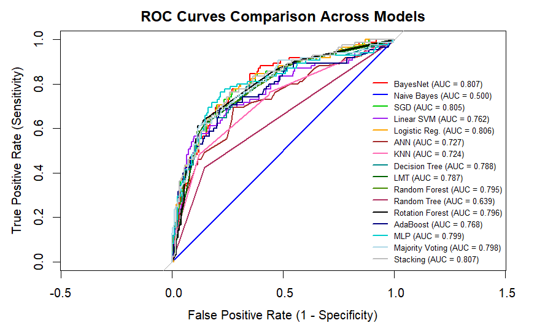

```r
# Construct legend with AUC scores
auc_labels <- sapply(names(models), function(m) {
  sprintf("%s (AUC = %.3f)", m, as.numeric(models[[m]]$auc))
})

legend(
  "bottomright",
  legend = auc_labels,
  col = colors,
  lwd = 2,
  cex = 0.65,
  bty = "n"
)
```

## Evaluation Metrics Table

```r
library(knitr)

# Define positive class label (e.g., "YES" or "1")
positive_class <- levels(test_set$LUNG_CANCER)[2]

neg_class <- levels(test_set$LUNG_CANCER)[1]

rotf_preds <- factor(
  ifelse(prob_rotf > 0.5, positive_class, neg_class),
  levels = levels(test_set$LUNG_CANCER)
)

# --- Helper Function to Extract Metrics safely from Confusion Matrix ---
get_metrics <- function(predictions, actual, pos_class) {
  cm <- confusionMatrix(predictions, actual, positive = pos_class)

  acc <- cm$overall["Accuracy"]
  prec <- cm$byClass["Precision"]
  rec  <- cm$byClass["Sensitivity"] # Sensitivity = Recall

  return(c(Accuracy = unname(acc), Precision = unname(prec), Recall = unname(rec)))
}

# --- Compile Predictions from All Models ---
# Assumes each model's predicted class factor vector is stored from earlier steps:
# Correct "Naive Bayes" test prediction
nb_preds <- predict(nb_model, newdata = test_set)

# Set predictions to the proper format
target_levels <- levels(test_set$LUNG_CANCER) # e.g., c("No", "Yes")

# Robust mapper to align all predictions to the exact reference levels
align_to_reference <- function(preds, ref_levels) {
  # Convert to character first to safely examine values
  preds_char <- as.character(preds)

  # Check if predictions are 0/1 while reference is No/Yes
  if (all(preds_char %in% c("0", "1", NA)) && all(ref_levels %in% c("No", "Yes"))) {
    preds_char <- ifelse(preds_char == "1", "Yes", "No")
  }
  # Check if predictions are No/Yes while reference is 0/1
  else if (all(preds_char %in% c("No", "Yes", NA)) && all(ref_levels %in% c("0", "1"))) {
    preds_char <- ifelse(preds_char == "Yes", "1", "0")
  }

  # Return factor with identical level structure
  factor(preds_char, levels = ref_levels)
}

models_preds <- list(
  "Naive Bayes"         = nb_preds,
  "BayesNet"            = bn_preds,
  "SGD"                 = sgd_preds,
  "Linear SVM"          = svm_preds,
  "Logistic Regression" = glm_preds,
  "ANN"                 = ann_preds,
  "KNN (K=3)"           = knn_preds,
  "C5.0 Tree"           = c50_preds,
  "Random Forest"       = rf_preds,
  "Random Tree"         = rt_preds,
  "REPTree"             = reptree_preds,
  "LMT (glmtree)"       = test_preds_lmt,
  "Rotation Forest"     = test_preds_rotf,
  "AdaBoost.M1"         = adaboost_preds,
  "ML Perceptron"       = mlp_preds,
  "Majority Voting"     = majority_preds,
  "Stacking"            = stack_preds
)

# Standardize all model prediction vectors to the reference levels
models_preds_clean <- lapply(models_preds, function(p) {
  align_to_reference(p, ref_levels = target_levels)
})

# Make sure pos_class matches an existing level in test_set
pos_class <- if ("Yes" %in% target_levels) "Yes" else target_levels[2]

# Compute metrics safely
results_list <- lapply(models_preds_clean, function(preds) {
  get_metrics(preds, test_set$LUNG_CANCER, pos_class = pos_class)
})

results_df <- do.call(rbind, results_list)
print(results_df)
```

```
                     Accuracy Precision    Recall
Naive Bayes         0.7376543        NA 0.0000000
BayesNet            0.8117284 0.6818182 0.5294118
SGD                 0.8055556 0.6964286 0.4588235
Linear SVM          0.8024691 0.6400000 0.5647059
Logistic Regression 0.7993827 0.6851852 0.4352941
ANN                 0.7716049 0.5873016 0.4352941
KNN (K=3)           0.7746914 0.5857143 0.4823529
C5.0 Tree           0.7839506 0.6315789 0.4235294
Random Forest       0.7962963 0.6666667 0.4470588
Random Tree         0.7407407 0.5070423 0.4235294
REPTree             0.7592593 0.5555556 0.4117647
LMT (glmtree)       0.7932099 0.6022727 0.6235294
Rotation Forest     0.7932099 0.6451613 0.4705882
AdaBoost.M1         0.8055556 0.7200000 0.4235294
ML Perceptron       0.7901235 0.6231884 0.5058824
Majority Voting     0.8055556 0.6774194 0.4941176
Stacking            0.8055556 0.7115385 0.4352941
```

```r
# Convert list to Data Frame
results_unselected <- data.frame(results_df) %>%
  tibble::rownames_to_column(var = "Model") %>%
  mutate(
    `F1 Score`= round((2 * Precision * Recall) / (Precision + Recall), 4),
    Accuracy  = round(Accuracy, 4),
    Precision = round(Precision, 4),
    Recall    = round(Recall, 4),
  ) %>%
  arrange(desc(Accuracy)) # Sort by highest accuracy
```

```r
# Render formatted HTML/Markdown table
kable_table <- kable(
  results_unselected,
  caption = "<b>Performance Statistics for Models Without Feature Selection</b>",
  col.names = c("Model", "Accuracy", "Precision", "Recall", "F1 Score"),
  align = c("l", "c", "c", "c", "c")
)

# Print the table
print(kable_table)
```

**Performance Statistics for Models Without Feature Selection**

| Model | Accuracy | Precision | Recall | F1 Score |
| --- | --- | --- | --- | --- |
| BayesNet | 0.8117 | 0.6818 | 0.5294 | 0.5960 |
| SGD | 0.8056 | 0.6964 | 0.4588 | 0.5532 |
| AdaBoost.M1 | 0.8056 | 0.7200 | 0.4235 | 0.5333 |
| Majority Voting | 0.8056 | 0.6774 | 0.4941 | 0.5714 |
| Stacking | 0.8056 | 0.7115 | 0.4353 | 0.5401 |
| Linear SVM | 0.8025 | 0.6400 | 0.5647 | 0.6000 |
| Logistic Regression | 0.7994 | 0.6852 | 0.4353 | 0.5324 |
| Random Forest | 0.7963 | 0.6667 | 0.4471 | 0.5352 |
| LMT (glmtree) | 0.7932 | 0.6023 | 0.6235 | 0.6127 |
| Rotation Forest | 0.7932 | 0.6452 | 0.4706 | 0.5442 |
| ML Perceptron | 0.7901 | 0.6232 | 0.5059 | 0.5584 |
| C5.0 Tree | 0.7840 | 0.6316 | 0.4235 | 0.5070 |
| KNN (K=3) | 0.7747 | 0.5857 | 0.4824 | 0.5290 |
| ANN | 0.7716 | 0.5873 | 0.4353 | 0.5000 |
| REPTree | 0.7593 | 0.5556 | 0.4118 | 0.4730 |
| Random Tree | 0.7407 | 0.5070 | 0.4235 | 0.4615 |
| Naive Bayes | 0.7377 | NA | 0.0000 | NA |

# 4. MODELS WITH FEATURE SELECTION

## Create Training Controls

```r
set.seed(123)
cv_folds <- createFolds(train_selected$LUNG_CANCER, k = 10, returnTrain = TRUE)

train_ctrl <- trainControl(
  method = "cv",
  index = cv_folds,
  classProbs = TRUE,
  summaryFunction = twoClassSummary,
  savePredictions = "final",
  verboseIter = FALSE
)
```

## Naive Bayes

```r
symptom_cols <- c("COPD", "SMOKER", "EXERCISE")

for (col in symptom_cols) {
  train_selected[[col]] <- factor(train_selected[[col]])
  test_selected[[col]]  <- factor(test_selected[[col]], levels = levels(train_selected[[col]]))
}

nb_grid <- expand.grid(
  laplace = c(0, 1, 2),
  usekernel = c(FALSE, TRUE),
  adjust = c(1, 1.5)
)

set.seed(123)
nb_model <- train(
  LUNG_CANCER ~ .,
  data = train_selected,
  method = "naive_bayes",
  trControl = train_ctrl,
  tuneGrid = nb_grid,
  metric = "ROC"
)

nb_preds <- predict(nb_model, newdata = test_selected)
confusionMatrix(nb_preds, test_selected$LUNG_CANCER, positive = "Yes")
```

```
Confusion Matrix and Statistics

          Reference
Prediction  No Yes
       No  207  35
       Yes  32  50

               Accuracy : 0.7932
                 95% CI : (0.745, 0.836)
    No Information Rate : 0.7377
    P-Value [Acc > NIR] : 0.01209

                  Kappa : 0.4596

 Mcnemar's Test P-Value : 0.80697

            Sensitivity : 0.5882
            Specificity : 0.8661
         Pos Pred Value : 0.6098
         Neg Pred Value : 0.8554
             Prevalence : 0.2623
         Detection Rate : 0.1543
   Detection Prevalence : 0.2531
      Balanced Accuracy : 0.7272

       'Positive' Class : Yes
```

## Bayesian Network (BayesNet)

```r
library(bnlearn)
library(pROC)
library(caret)

# 1. Prepare data frames
train_bn <- train_selected
test_bn  <- test_selected

# Ensure BMI is numeric before discretizing
train_bn$BMI <- as.numeric(train_bn$BMI)
test_bn$BMI  <- as.numeric(test_bn$BMI)

# Factorize all other categorical/symptom columns
factor_cols <- setdiff(names(train_bn), c("BMI", "LUNG_CANCER"))
train_bn[factor_cols] <- lapply(train_bn[factor_cols], factor)
test_bn[factor_cols]  <- lapply(test_bn[factor_cols], factor)

# 2. Discretize BMI into 3 quantile bins using bnlearn
train_bn["BMI"] <- bnlearn::discretize(
  data = train_bn["BMI"],
  method = "quantile",
  breaks = 3,
  ordered = FALSE
)

# Project training quantile boundaries onto test_selected$BMI
raw_train_vals <- as.numeric(train_selected$BMI)
brks <- quantile(raw_train_vals, probs = seq(0, 1, length.out = 4), na.rm = TRUE)
brks[1] <- -Inf
brks[length(brks)] <- Inf

test_bn$BMI <- cut(
  as.numeric(test_selected$BMI),
  breaks = brks,
  labels = levels(train_bn$BMI),
  include.lowest = TRUE
)

# Ensure test_bn factor levels match train_bn perfectly
for (col in names(train_bn)) {
  if (is.factor(train_bn[[col]])) {
    test_bn[[col]] <- factor(test_bn[[col]], levels = levels(train_bn[[col]]))
  }
}

target_node <- "LUNG_CANCER"
bn_cv_acc <- numeric(10)

# 3. 10-Fold Cross-Validation Loop
for (i in 1:10) {
  val_idx    <- cv_folds[[i]]
  fold_train <- train_bn[val_idx, , drop = FALSE]
  fold_val   <- train_bn[-val_idx, , drop = FALSE]

  # Remove single-level columns if any exist in the fold
  single_level <- sapply(fold_train, function(x) length(unique(x)) < 2)
  if (any(single_level)) {
    fold_train <- fold_train[, !single_level, drop = FALSE]
    fold_val   <- fold_val[, intersect(names(fold_train), names(fold_val)), drop = FALSE]
  }

  # Harmonize factor levels between fold train and val
  for (col in names(fold_train)) {
    if (is.factor(fold_train[[col]])) {
      fold_val[[col]] <- factor(fold_val[[col]], levels = levels(fold_train[[col]]))
    }
  }

  # Learn structure and fit parameters
  fit_res <- tryCatch({
    dag <- hc(fold_train)
    bn.fit(dag, data = fold_train, method = "bayes", iss = 1)
  }, error = function(e) NULL)

  if (is.null(fit_res)) {
    bn_cv_acc[i] <- NA
    next
  }

  # Predict via likelihood weighting
  preds <- tryCatch({
    predict(fit_res, node = target_node, data = fold_val, method = "bayes-lw")
  }, error = function(e) NULL)

  if (!is.null(preds)) {
    bn_cv_acc[i] <- mean(preds == fold_val[[target_node]], na.rm = TRUE)
  } else {
    bn_cv_acc[i] <- NA
  }
}

cat("BayesNet 10-Fold CV Mean Accuracy:", mean(bn_cv_acc, na.rm = TRUE), "\n")
```

```
BayesNet 10-Fold CV Mean Accuracy: 0.7838473
```

```r
# 4. Final Model Training and Test Evaluation
dag_final <- hc(train_bn)
bn_final  <- bn.fit(dag_final, data = train_bn, method = "bayes", iss = 1)

bn_preds <- predict(bn_final, node = target_node, data = test_bn, method = "bayes-lw")

confusionMatrix(bn_preds, test_bn[[target_node]], positive = "Yes")
```

```
Confusion Matrix and Statistics

          Reference
Prediction  No Yes
       No  218  40
       Yes  21  45

               Accuracy : 0.8117
                 95% CI : (0.7648, 0.8528)
    No Information Rate : 0.7377
    P-Value [Acc > NIR] : 0.001106

                  Kappa : 0.4758

 Mcnemar's Test P-Value : 0.021185

            Sensitivity : 0.5294
            Specificity : 0.9121
         Pos Pred Value : 0.6818
         Neg Pred Value : 0.8450
             Prevalence : 0.2623
         Detection Rate : 0.1389
   Detection Prevalence : 0.2037
      Balanced Accuracy : 0.7208

       'Positive' Class : Yes
```

## Stochastic Gradient Descent (SGD)

```r
library(LiblineaR)
library(caret)

# ---------------------------------------------------------
# 1. Recode 0/1 to Valid R Variable Names ("No" / "Yes")
# ---------------------------------------------------------
train_sgd_selected <- train_selected
test_sgd_selected <- test_selected

if (!all(levels(train_sgd_selected$LUNG_CANCER) %in% c("No", "Yes"))) {
  train_sgd_selected$LUNG_CANCER <- factor(train_sgd_selected$LUNG_CANCER,
                                  levels = c("0", "1"),
                                  labels = c("No", "Yes"))

  test_sgd_selected$LUNG_CANCER  <- factor(test_sgd_selected$LUNG_CANCER,
                                  levels = c("0", "1"),
                                  labels = c("No", "Yes"))
}

# ---------------------------------------------------------
# 2. Configure trainControl
# ---------------------------------------------------------
train_ctrl <- trainControl(
  method = "cv",
  number = 10,
  classProbs = TRUE,
  summaryFunction = twoClassSummary,
  savePredictions = "final",
  verboseIter = FALSE
)

# ---------------------------------------------------------
# 3. Train Regularized Logistic Regression (SGD Equivalent)
# ---------------------------------------------------------
set.seed(123)
sgd_model <- train(
  LUNG_CANCER ~ .,
  data = train_sgd_selected,
  method = "regLogistic",
  preProcess = c("center", "scale"),
  tuneGrid = expand.grid(
    cost = 1 / (1e-4 * nrow(train_sgd_selected)),
    loss = "L2_dual",
    epsilon = 0.01
  ),
  trControl = train_ctrl,
  metric = "ROC"
)

# ---------------------------------------------------------
# 4. Predict & Evaluate
# ---------------------------------------------------------
sgd_preds <- predict(sgd_model, newdata = test_sgd_selected)

# positive = "Yes" matches the second factor level
conf_matrix_sgd <- confusionMatrix(sgd_preds, test_sgd_selected$LUNG_CANCER, positive = "Yes")
print(conf_matrix_sgd)
```

```
Confusion Matrix and Statistics

          Reference
Prediction  No Yes
       No  222  46
       Yes  17  39

               Accuracy : 0.8056
                 95% CI : (0.7582, 0.8472)
    No Information Rate : 0.7377
    P-Value [Acc > NIR] : 0.0026386

                  Kappa : 0.4356

 Mcnemar's Test P-Value : 0.0004192

            Sensitivity : 0.4588
            Specificity : 0.9289
         Pos Pred Value : 0.6964
         Neg Pred Value : 0.8284
             Prevalence : 0.2623
         Detection Rate : 0.1204
   Detection Prevalence : 0.1728
      Balanced Accuracy : 0.6938

       'Positive' Class : Yes
```

## Support Vector Machine (SVM)

```r
svm_model <- train(
  LUNG_CANCER ~ .,
  data = train_sgd_selected,
  method = "svmLinear2", # Uses e1071 backend instead of kernlab
  preProcess = c("center", "scale"),
  tuneGrid = expand.grid(cost = 1.0),
  trControl = train_ctrl,
  probability = TRUE
)

svm_preds <- predict(svm_model, newdata = test_sgd_selected)

conf_matrix_svm <- confusionMatrix(svm_preds, test_sgd_selected$LUNG_CANCER)
print(conf_matrix_svm)
```

```
Confusion Matrix and Statistics

          Reference
Prediction  No Yes
       No  212  37
       Yes  27  48

               Accuracy : 0.8025
                 95% CI : (0.7549, 0.8444)
    No Information Rate : 0.7377
    P-Value [Acc > NIR] : 0.003965

                  Kappa : 0.4695

 Mcnemar's Test P-Value : 0.260589

            Sensitivity : 0.8870
            Specificity : 0.5647
         Pos Pred Value : 0.8514
         Neg Pred Value : 0.6400
             Prevalence : 0.7377
         Detection Rate : 0.6543
   Detection Prevalence : 0.7685
      Balanced Accuracy : 0.7259

       'Positive' Class : No
```

## Logistic Regression

```r
lr_model <- train(
  LUNG_CANCER ~ .,
  data = train_sgd_selected,
  method = "glmnet",
  family = "binomial",
  tuneGrid = expand.grid(alpha = 0, lambda = 1e-8),
  trControl = train_ctrl
)

glm_preds <- predict(lr_model, newdata = test_sgd_selected)

conf_matrix_lr <- confusionMatrix(glm_preds, test_sgd_selected$LUNG_CANCER)
print(conf_matrix_lr)
```

```
Confusion Matrix and Statistics

          Reference
Prediction  No Yes
       No  223  47
       Yes  16  38

               Accuracy : 0.8056
                 95% CI : (0.7582, 0.8472)
    No Information Rate : 0.7377
    P-Value [Acc > NIR] : 0.0026386

                  Kappa : 0.4307

 Mcnemar's Test P-Value : 0.0001571

            Sensitivity : 0.9331
            Specificity : 0.4471
         Pos Pred Value : 0.8259
         Neg Pred Value : 0.7037
             Prevalence : 0.7377
         Detection Rate : 0.6883
   Detection Prevalence : 0.8333
      Balanced Accuracy : 0.6901

       'Positive' Class : No
```

## Artificial Neural Network (ANN)

```r
num_attributes <- ncol(train_selected) - 1
num_classes    <- length(levels(train_selected$LUNG_CANCER))
hidden_a       <- round((num_attributes + num_classes) / 2)

ann_model <- train(
  LUNG_CANCER ~ .,
  data = train_sgd_selected,
  method = "nnet",
  preProcess = c("center", "scale"),
  tuneGrid = expand.grid(size = hidden_a, decay = 0.0),
  maxit = 500,
  trace = FALSE,
  trControl = train_ctrl
)

ann_preds <- predict(ann_model, newdata = test_sgd_selected)

conf_matrix_ann <- confusionMatrix(ann_preds, test_sgd_selected$LUNG_CANCER)
print(conf_matrix_ann)
```

```
Confusion Matrix and Statistics

          Reference
Prediction  No Yes
       No  204  35
       Yes  35  50

               Accuracy : 0.784
                 95% CI : (0.7351, 0.8275)
    No Information Rate : 0.7377
    P-Value [Acc > NIR] : 0.03162

                  Kappa : 0.4418

 Mcnemar's Test P-Value : 1.00000

            Sensitivity : 0.8536
            Specificity : 0.5882
         Pos Pred Value : 0.8536
         Neg Pred Value : 0.5882
             Prevalence : 0.7377
         Detection Rate : 0.6296
   Detection Prevalence : 0.7377
      Balanced Accuracy : 0.7209

       'Positive' Class : No
```